# Single-Cell RNAseq QC and filtering

# Load Libraries

```r
library(Seurat)
library(cowplot)
library(stringr)
library(ggplot2)
library(tidyverse)
library(DoubletFinder)
library(gridExtra)
saved.seed <- 6789
```

# Paths to data

```r
path_General <- "G:\\Shared drives\\Gonzalez-Vicente public data\\Paper0501_Caloric Restriction\\00_Data and QC"

path_KMY  <- paste(path_General, "1_GSM4331828_Kidney-M-Y\\00_Matrices", sep = "\\")   %>% print()
```

```
[1] "G:\\Shared drives\\Gonzalez-Vicente public data\\Paper0501_Caloric Restriction\\00_Data and QC\\1_GSM4331828_Kidney-M-Y\\00_Matrices"
```

```r
path_KMO  <- paste(path_General, "2_GSM4331829_Kidney-M-O\\00_Matrices", sep = "\\")   %>% print()
```

```
[1] "G:\\Shared drives\\Gonzalez-Vicente public data\\Paper0501_Caloric Restriction\\00_Data and QC\\2_GSM4331829_Kidney-M-O\\00_Matrices"
```

```r
path_KMCR <- paste(path_General, "3_GSM4331830_Kidney-M-CR\\00_Matrices", sep = "\\")  %>% print()
```

```
[1] "G:\\Shared drives\\Gonzalez-Vicente public data\\Paper0501_Caloric Restriction\\00_Data and QC\\3_GSM4331830_Kidney-M-CR\\00_Matrices"
```

```r
path_KFY  <- paste(path_General, "4_GSM4331831_Kidney-F-Y\\00_Matrices", sep = "\\")   %>% print()
```

```
[1] "G:\\Shared drives\\Gonzalez-Vicente public data\\Paper0501_Caloric Restriction\\00_Data and QC\\4_GSM4331831_Kidney-F-Y\\00_Matrices"
```

```r
path_KFO  <- paste(path_General, "5_GSM4331832_Kidney-F-O\\00_Matrices", sep = "\\")   %>% print()
```

```
[1] "G:\\Shared drives\\Gonzalez-Vicente public data\\Paper0501_Caloric Restriction\\00_Data and QC\\5_GSM4331832_Kidney-F-O\\00_Matrices"
```

```r
path_KFCR <- paste(path_General, "6_GSM4331833_Kidney-F-CR\\00_Matrices", sep = "\\")  %>% print()
```

```
[1] "G:\\Shared drives\\Gonzalez-Vicente public data\\Paper0501_Caloric Restriction\\00_Data and QC\\6_GSM4331833_Kidney-F-CR\\00_Matrices"
```

# Import data and create Seruat objects

```r
KMY <- CreateSeuratObject(Read10X(data.dir = path_KMY),
                          min.cells = 3,        #Include features detected in at least this many cells
                          min.features = 200)   #Include cells where at least this many features are detected
KMY$Sample <- "Young.M.AL"
KMY$Sex <- "Male"
KMY$Age <- "Young"
KMY$Diet <- "Ad.Libitum"

KMO <- CreateSeuratObject(Read10X(data.dir = path_KMO),
                          min.cells = 3,        #Include features detected in at least this many cells
                          min.features = 200)   #Include cells where at least this many features are detected
KMO$Sample <- "Old.M.AL"
KMO$Sex <- "Male"
KMO$Age <- "Old"
KMO$Diet <- "Ad.Libitum"

KMCR <- CreateSeuratObject(Read10X(data.dir = path_KMCR),
                          min.cells = 3,        #Include features detected in at least this many cells
                          min.features = 200)   #Include cells where at least this many features are detected
KMCR$Sample <- "Old.M.CR"
KMCR$Sex <- "Male"
KMCR$Age <- "Old"
KMCR$Diet <- "Restricted"

KFY <- CreateSeuratObject(Read10X(data.dir = path_KFY),
                          min.cells = 3,        #Include features detected in at least this many cells
                          min.features = 200)   #Include cells where at least this many features are detected
KFY$Sample <- "Young.F.AL"
KFY$Sex <- "Female"
KFY$Age <- "Young"
KFY$Diet <- "Ad.Libitum"

KFO <- CreateSeuratObject(Read10X(data.dir = path_KFO),
                          min.cells = 3,        #Include features detected in at least this many cells
                          min.features = 200)   #Include cells where at least this many features are detected
KFO$Sample <- "Old.F.AL"
KFO$Sex <- "Female"
KFO$Age <- "Old"
KFO$Diet <- "Ad.Libitum"

KFCR <- CreateSeuratObject(Read10X(data.dir = path_KFCR),
                          min.cells = 3,        #Include features detected in at least this many cells
                          min.features = 200)   #Include cells where at least this many features are detected
KFCR$Sample <- "Old.F.CR"
KFCR$Sex <- "Female"
KFCR$Age <- "Old"
KFCR$Diet <- "Restricted"
```

# Merge datasets into one single Seurat object

```r
all.merged <- merge(KMY, c(KMO,KMCR,KFY,KFO,KFCR))
```

# Dimensions

```r
dim(all.merged)
```

```
[1] 16821 19414
```

```r
table(all.merged$Sample, all.merged$orig.ident)
```

```
             SeuratProject
  Old.F.AL            1186
  Old.F.CR            3501
  Old.M.AL            3662
  Old.M.CR            4500
  Young.F.AL          2931
  Young.M.AL          3634
```

# Clean Environment

```r
rm(path_KFCR, path_KFO, path_KFY, path_KMCR, path_KMO, path_KMY)
rm(KMY,KMO,KMCR,KFY,KFO,KFCR)
gc(verbose = T)
```

```
Garbage collection 83 = 43+14+26 (level 2) ...
187.2 Mbytes of cons cells used (51%)
881.5 Mbytes of vectors used (39%)
```

```
            used  (Mb) gc trigger   (Mb)  max used   (Mb)
Ncells   3504541 187.2    6822682  364.4   5282744  282.2
Vcells 115538065 881.5  297253056 2267.9 243963330 1861.3
```

# QC metrics

## Ammount of mitochondrial genes

```r
grep("^Mt-",
     rownames(all.merged@assays$RNA@counts),
     value = T)
```

```
 [1] "Mt-nd1"  "Mt-nd2"  "Mt-co1"  "Mt-co2"  "Mt-atp8" "Mt-atp6" "Mt-co3"  "Mt-nd3"  "Mt-nd4l" "Mt-nd4"  "Mt-nd5"
[12] "Mt-nd6"  "Mt-cyb"
```

```r
all.merged <- PercentageFeatureSet(all.merged, "^Mt-",
                                     col.name = "percent.MT")
head(all.merged$percent.MT)
```

```
AAACCTGAGCCGTCGT_Kidney_M_Y AAACCTGCACTGCCAG_Kidney_M_Y AAACCTGCAGACAAAT_Kidney_M_Y AAACCTGCAGGTCCAC_Kidney_M_Y
                  31.190798                   18.490170                    4.022359                   94.255819
AAACCTGTCACAGGCC_Kidney_M_Y AAACCTGTCCCGGATG_Kidney_M_Y
                  35.425948                   36.197627
```

## Ammount of ribosomal genes

Ribosomal genes tend to be very highly represented, and can vary between cell types. These are ribosomal protein genes rather than the actual rRNA, so they’re more a measure of the translational activity of the cell rather than the cleanliness of the polyA selection.

```r
grep("^Rp[sl]",
     rownames(all.merged@assays$RNA@counts),
     value = T)
```

```
 [1] "Rps12"    "Rps6ka2"  "Rps9"     "Rps5"     "Rpl28"    "Rps19"    "Rps16"    "Rps11"    "Rpl13a"   "Rpl18"
[11] "Rps17"    "Rps3"     "Rpl27a"   "Rps15a"   "Rplp2"    "Rpl35al1" "Rps6kb2"  "Rps6ka4"  "Rps23"    "Rps15al4"
[21] "Rpl22l1"  "Rps3a"    "Rps27"    "Rplp0l1"  "Rpl34"    "Rps4x"    "Rpl32"    "Rps4y2"   "Rps13"    "Rpl7a.1"
[31] "Rpl12"    "Rpl35"    "Rpl21"    "Rps21"    "Rpl7"     "Rps20"    "Rps6"     "Rps8"     "Rps27a"   "Rps6ka1"
[41] "Rpl11"    "Rpl21.1"  "Rps6ka3"  "Rps4x.1"  "Rps6ka6"  "Rpl36al"  "Rpl10"    "Rps10l1"  "Rps6ka5"  "Rpl32.1"
[51] "Rpl41"    "Rps15"    "Rps28"    "Rpl3"     "Rps19bp1" "Rps25"    "Rpl4"     "Rps27l"   "Rpl29"    "Rpsa"
[61] "Rpl14"    "Rpl36"    "Rpl7l1"   "Rps19.1"  "Rpl31"    "Rpl37a"   "Rpl5"     "Rpl9"     "Rps27a.1" "Rpl21.2"
[71] "Rps29"    "Rps6kc1"  "Rpl39l"   "Rps2"     "Rpl3l"    "Rpl30"    "Rpl26"    "Rpl36a"   "Rpl23a"   "Rps6kb1"
[81] "Rpl23"    "Rpl19"    "Rpl27"    "Rps18l1"  "Rpl15"    "Rps24"    "Rpl18a"   "Rpl24"    "Rpl17"    "Rpl13"
[91] "Rps18"    "Rps10"    "Rpl10a"   "Rpl21.3"  "Rpl6"     "Rplp0"    "Rpl10l"   "Rps6kl1"  "Rpl30l1"
```

```r
all.merged <- PercentageFeatureSet(all.merged, "^Rp[sl]",
                                     col.name = "percent.Ribosomal")
head(all.merged$percent.Ribosomal)
```

```
AAACCTGAGCCGTCGT_Kidney_M_Y AAACCTGCACTGCCAG_Kidney_M_Y AAACCTGCAGACAAAT_Kidney_M_Y AAACCTGCAGGTCCAC_Kidney_M_Y
                  4.9503834                   5.5980789                  21.7777291                   0.4697843
AAACCTGTCACAGGCC_Kidney_M_Y AAACCTGTCCCGGATG_Kidney_M_Y
                  3.6316997                   9.5198369
```

## Percentage of Largest Gene

Run apply() over the columns (cells) and calculate what percentage of the data comes from the single most observed gene. Exclude Malat1 as it is usually highly expressed and affects results We will get: The count for the largest gene per cell The index position of the gene with the largest count The name of the most highly expressed gene per cell

```r
all.merged[rownames(all.merged) != "Malat1",] -> SObject.F

apply(
  SObject.F@assays$RNA@counts,
  2,
  max) -> SObject.F$largest_count
apply(
  SObject.F@assays$RNA@counts,
  2,
  which.max) -> SObject.F$largest_index
rownames(SObject.F)[SObject.F$largest_index] -> SObject.F$largest_gene
100 * SObject.F$largest_count / SObject.F$nCount_RNA -> SObject.F$percent.Largest.Gene

SObject.F$largest_gene -> all.merged$largest_gene

SObject.F$percent.Largest.Gene -> all.merged$percent.Largest.Gene
rm(SObject.F)
```

## Plot QC metrics

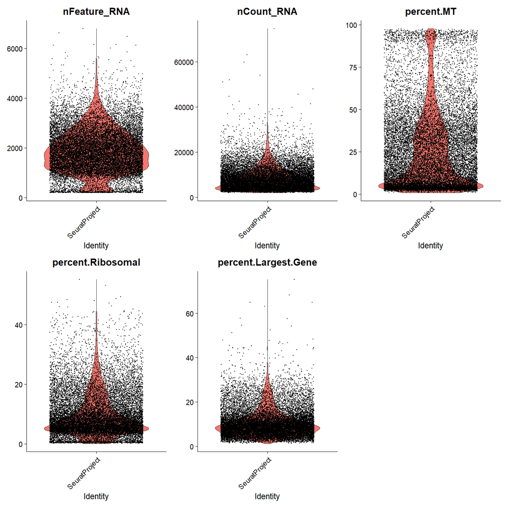

```r
VlnPlot(all.merged,
        features=c("nFeature_RNA",
                   "nCount_RNA",
                   "percent.MT",
                   "percent.Ribosomal",
                   "percent.Largest.Gene"),
        ncol = 3)
```

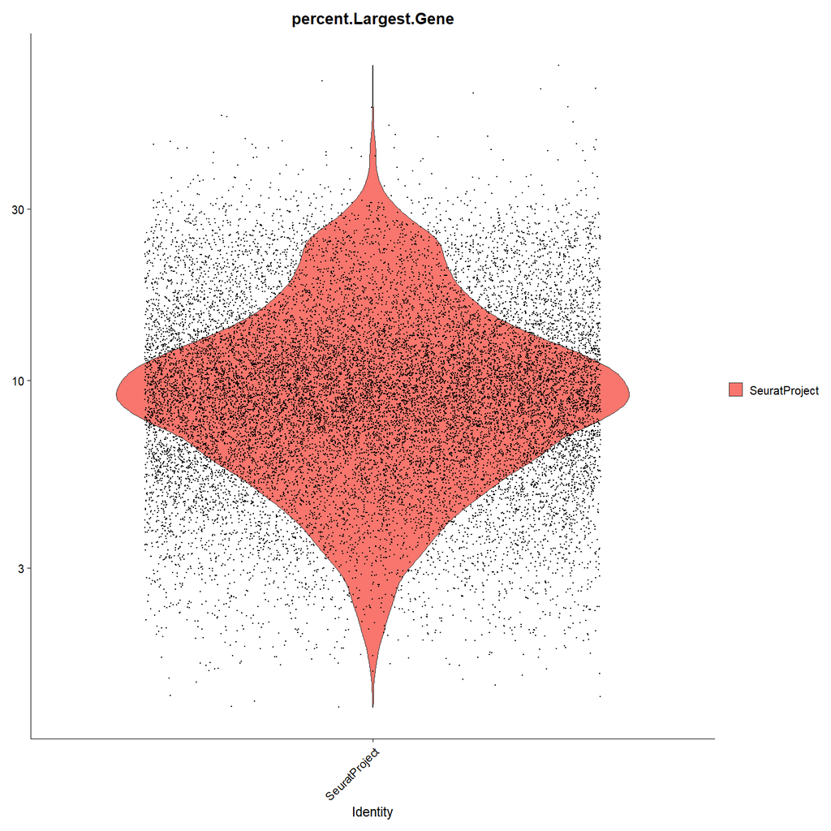

```r
VlnPlot(all.merged,
        features=c("percent.Largest.Gene"),
        ncol = 1) +
  scale_y_log10()
```

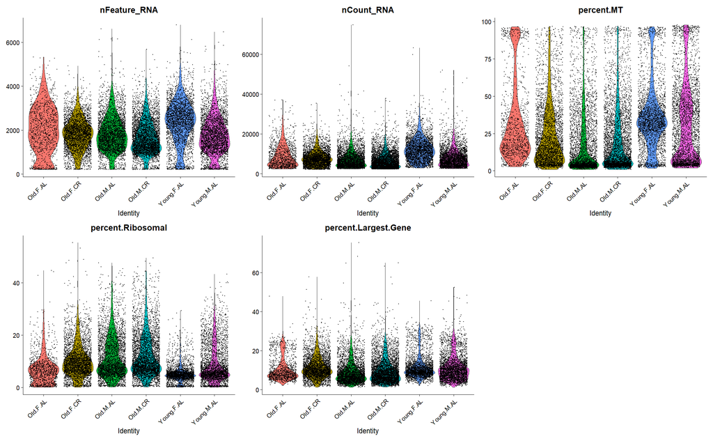

```r
VlnPlot(all.merged,
        features=c("nFeature_RNA",
                   "nCount_RNA",
                   "percent.MT",
                   "percent.Ribosomal",
                   "percent.Largest.Gene"),
        group.by = "Sample",
        ncol = 3)
```

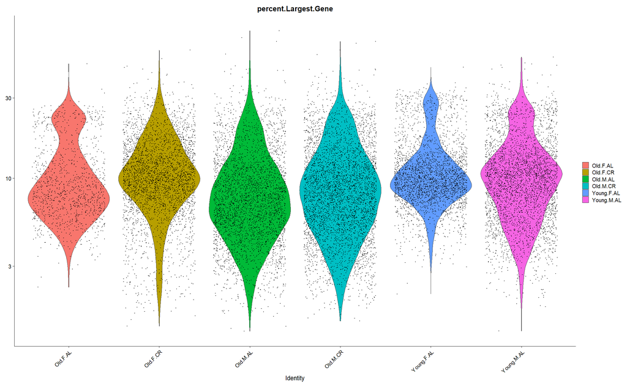

```r
VlnPlot(all.merged,
        features=c("percent.Largest.Gene"),
        group.by = "Sample",
        ncol = 1) +
  scale_y_log10()
```

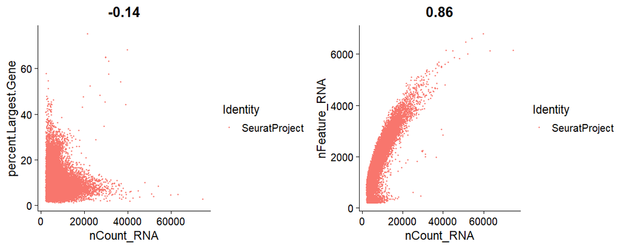

```r
grid.arrange(
FeatureScatter(all.merged,
               feature1 = "nCount_RNA",
               feature2 = "percent.Largest.Gene",
               group.by = "orig.ident",
               pt.size = 0.5),

FeatureScatter(all.merged,
               "nCount_RNA",
               "nFeature_RNA",
               group.by = "orig.ident",
               pt.size = 0.5),
ncol = 2)
```

## QC plots using ggplot2

```r
qc.metrics <- as_tibble( all.merged[[]], rownames="Cell.Barcode")
head(qc.metrics)
```

| Cell.Barcode | orig.ident | nCount_RNA | nFeature_RNA | Sample | Sex | Age | Diet | percent.MT | percent.Ribosomal | largest_gene | percent.Largest.Gene |
| --- | --- | --- | --- | --- | --- | --- | --- | --- | --- | --- | --- |
| AAACCTGAGCCGTCGT_Kidney_M_Y | SeuratProject | 8868 | 2288 | Young.M.AL | Male | Young | Ad.Libitum | 31.190798 | 4.9503834 | Mt-atp6 | 8.085250 |
| AAACCTGCACTGCCAG_Kidney_M_Y | SeuratProject | 6663 | 2039 | Young.M.AL | Male | Young | Ad.Libitum | 18.490170 | 5.5980789 | AC134224.3 | 9.034969 |
| AAACCTGCAGACAAAT_Kidney_M_Y | SeuratProject | 9124 | 2198 | Young.M.AL | Male | Young | Ad.Libitum | 4.022359 | 21.7777291 | Tmsb4x | 4.088119 |
| AAACCTGCAGGTCCAC_Kidney_M_Y | SeuratProject | 4683 | 223 | Young.M.AL | Male | Young | Ad.Libitum | 94.255819 | 0.4697843 | Mt-atp6 | 24.813154 |
| AAACCTGTCACAGGCC_Kidney_M_Y | SeuratProject | 7407 | 2076 | Young.M.AL | Male | Young | Ad.Libitum | 35.425948 | 3.6316997 | Mt-co1 | 8.113946 |
| AAACCTGTCCCGGATG_Kidney_M_Y | SeuratProject | 10788 | 2356 | Young.M.AL | Male | Young | Ad.Libitum | 36.197627 | 9.5198369 | Mt-atp6 | 8.092325 |

## nFeatures vs. nCounts

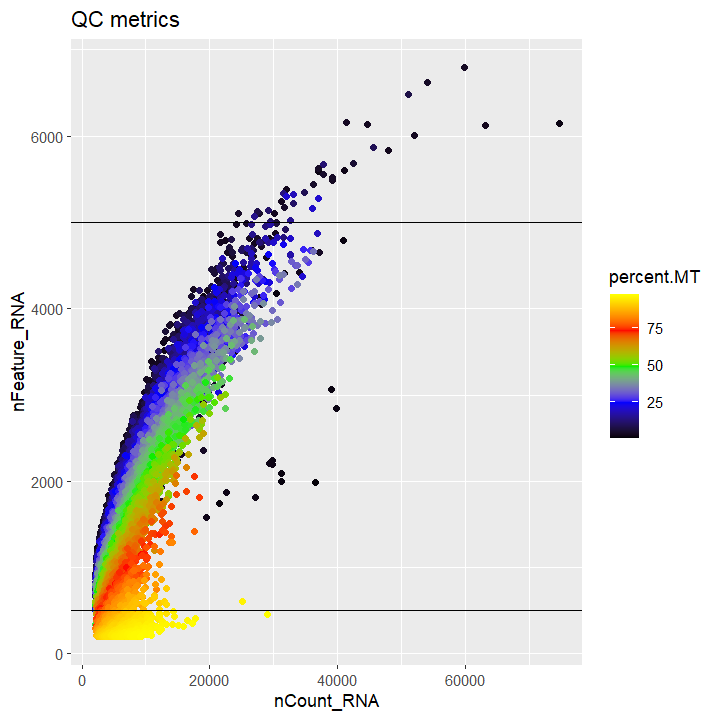

```r
qc.metrics %>%
  arrange(percent.MT) %>%
  ggplot(aes(nCount_RNA,nFeature_RNA,colour=percent.MT)) +
  geom_point() +
  scale_color_gradientn(colors=c("black" , "blue" , "green2" , "red" , "yellow")) +
  ggtitle("QC metrics") +
  geom_hline(yintercept = 500) +
  geom_hline(yintercept = 5000)
```

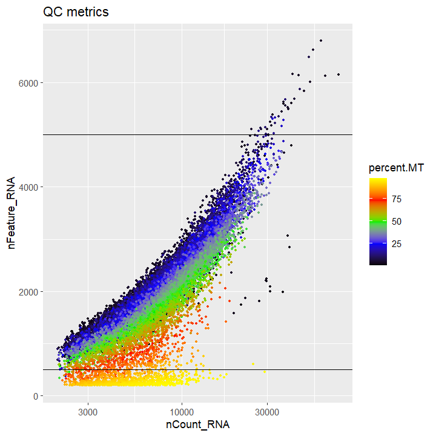

```r
qc.metrics %>%
  arrange(percent.MT) %>%
  ggplot(aes(nCount_RNA,nFeature_RNA,colour=percent.MT)) +
  geom_point(size=0.7) +
  scale_color_gradientn(colors=c("black" , "blue" , "green2" , "red" , "yellow")) +
  ggtitle("QC metrics") +
  geom_hline(yintercept = 500) +
  geom_hline(yintercept = 5000) +
  scale_y_continuous() +
  scale_x_log10()
```

## Complexity: log10(genes)/log10(counts)

```r
qc.metrics %>%
  mutate(complexity=log10(nFeature_RNA) / log10(nCount_RNA)) -> qc.metrics

lm(log10(qc.metrics$nFeature_RNA)~log10(qc.metrics$nCount_RNA)) -> complexity.lm

complexity.lm
```

```
Call:
lm(formula = log10(qc.metrics$nFeature_RNA) ~ log10(qc.metrics$nCount_RNA))

Coefficients:
                 (Intercept)  log10(qc.metrics$nCount_RNA)
                      0.3028                        0.7565
```

```r
qc.metrics %>%
  mutate(
    complexity_diff = log10(nFeature_RNA) - ((log10(qc.metrics$nCount_RNA)*complexity.lm$coefficients[2])+complexity.lm$coefficients[1])
    ) -> qc.metrics
```

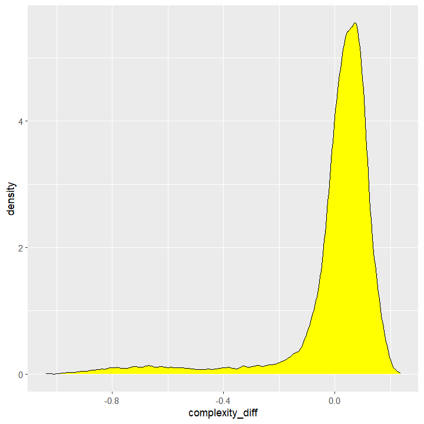

```r
qc.metrics %>%
  ggplot(aes(x=complexity_diff)) +
  geom_density(fill="yellow")
```

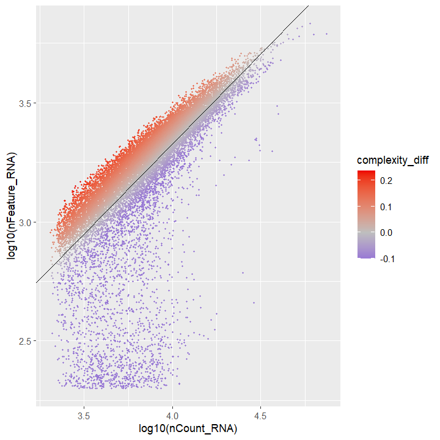

```r
min(c(max(qc.metrics$complexity_diff),0-min(qc.metrics$complexity_diff))) -> complexity_scale

qc.metrics %>%
  mutate(complexity_diff=replace(complexity_diff,complexity_diff< -0.1,-0.1)) %>%
  ggplot(aes(x=log10(nCount_RNA), y=log10(nFeature_RNA), colour=complexity_diff)) +
  geom_point(size=0.5) +
  geom_abline(slope=complexity.lm$coefficients[2], intercept = complexity.lm$coefficients[1]) +
  scale_colour_gradient2(low="blue2",mid="grey",high="red2")
```

### Note: 10^2.75 = 562…. this may be a value that make sense for subset(nFeatures_RNA > 560)… Also, nCounts_RNA < 30000 (10^4.5)?

# Largest Gene

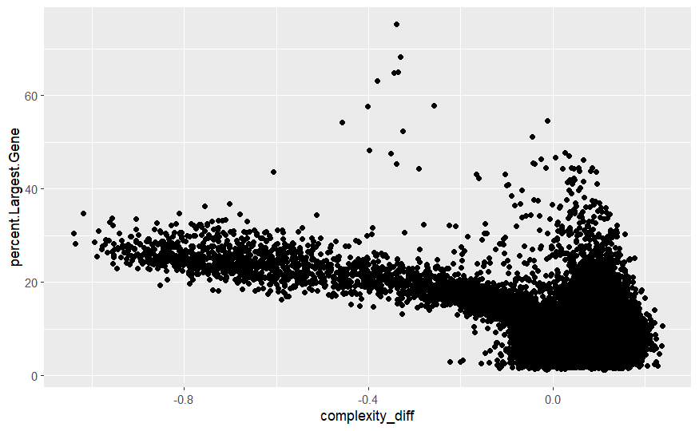

```r
qc.metrics %>%
  ggplot(aes(x=complexity_diff,
             y=percent.Largest.Gene)) +
  geom_point()
```

```r
qc.metrics %>%
  group_by(largest_gene) %>%
  count() %>%
  arrange(desc(n)) -> largest_gene_list
largest_gene_list
```

| largest_gene | n |
| --- | --- |
| AC134224.3 | 9637 |
| Mt-atp6 | 7526 |
| Tmsb4x | 644 |
| Lyz2 | 502 |
| Mt-co3 | 291 |
| Gpx3 | 148 |
| Cd74 | 127 |
| Fth1 | 114 |
| Mt-co1 | 71 |
| Ccl5 | 44 |

[output cut: 36 more lines]

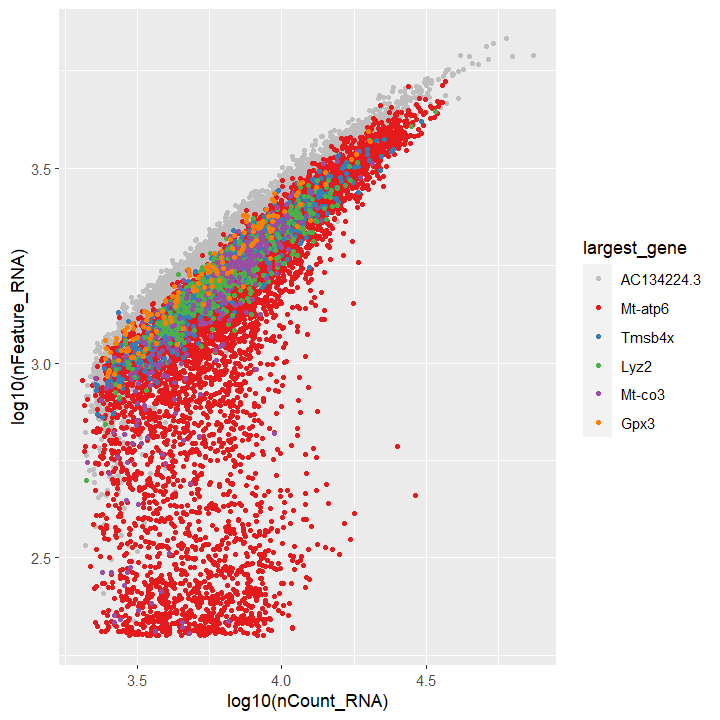

```r
largest_gene_list %>%
  filter(n>140) %>%
  pull(largest_gene) -> largest_genes_to_plot

qc.metrics %>%
  filter(largest_gene %in% largest_genes_to_plot) %>%
  mutate(largest_gene=factor(largest_gene, levels=largest_genes_to_plot)) %>%
  arrange(largest_gene) %>%
  ggplot(aes(x=log10(nCount_RNA), y=log10(nFeature_RNA), colour=largest_gene)) +
  geom_point(size=1) +
  scale_colour_manual(values=c("grey", RColorBrewer::brewer.pal(9,"Set1")))
```

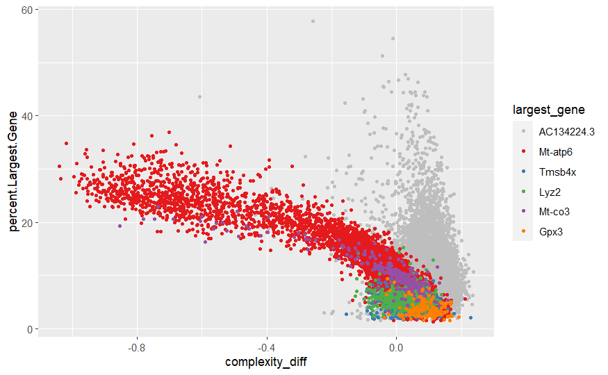

```r
qc.metrics %>%
  filter(largest_gene %in% largest_genes_to_plot) %>%
  mutate(largest_gene=factor(largest_gene, levels=largest_genes_to_plot)) %>%
  arrange(largest_gene) %>%
  ggplot(aes(x=complexity_diff,
             y=percent.Largest.Gene,
             colour=largest_gene)) +
  geom_point(size=1) +
  scale_colour_manual(values=c("grey", RColorBrewer::brewer.pal(9,"Set1")))
```

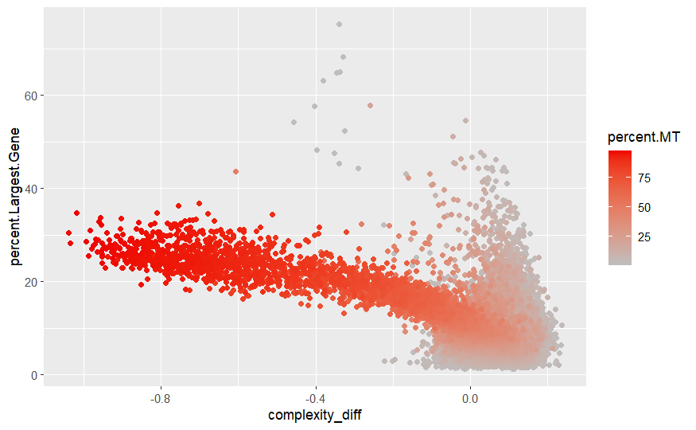

```r
qc.metrics %>%
  arrange(percent.MT) %>%
  ggplot(aes(x=complexity_diff, y=percent.Largest.Gene, colour=percent.MT)) +
  geom_point() +
  scale_colour_gradient(low="grey", high="red2")
```

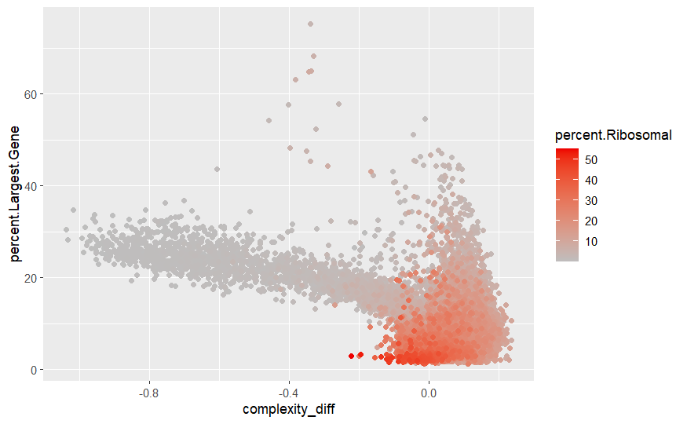

```r
qc.metrics %>%
  arrange(percent.Ribosomal) %>%
  ggplot(aes(x=complexity_diff,
             y=percent.Largest.Gene,
             colour = percent.Ribosomal)) +
  geom_point() +
  scale_colour_gradient(low="grey", high="red2")
```

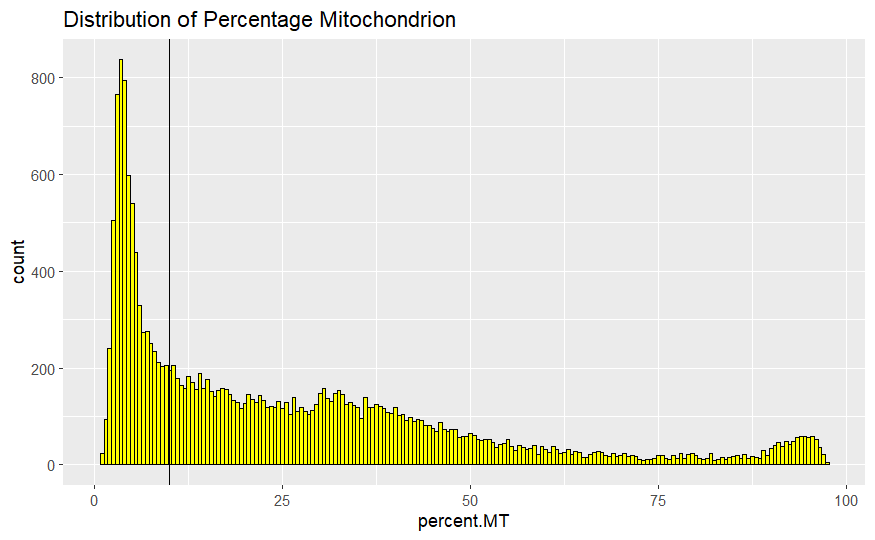

```r
qc.metrics %>%
  ggplot(aes(percent.MT)) +
  geom_histogram(binwidth =0.5, fill="yellow", colour="black") +
  ggtitle("Distribution of Percentage Mitochondrion") +
  geom_vline(xintercept =10)
```

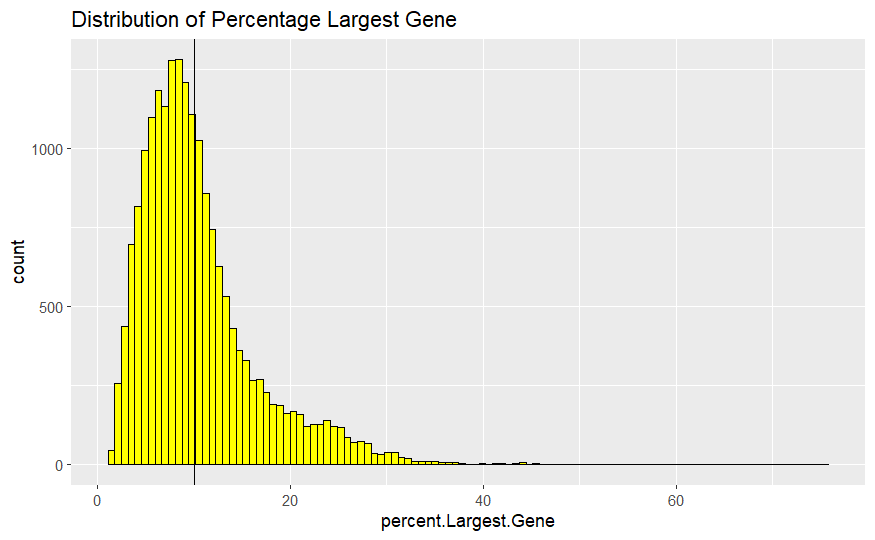

```r
qc.metrics %>%
  ggplot(aes(percent.Largest.Gene)) +
  geom_histogram(binwidth =0.7, fill="yellow", colour="black") +
  ggtitle("Distribution of Percentage Largest Gene") +
  geom_vline(xintercept =10)
```

# Filter Seurat object

```r
all.merged
```

```
An object of class Seurat
16821 features across 19414 samples within 1 assay
Active assay: RNA (16821 features, 0 variable features)
```

```r
all.filtered <- subset(all.merged,
                       nFeature_RNA > 560 &
                         nFeature_RNA < 4500 &
                         nCount_RNA < 30000 &
                         percent.MT < 40 &
                         percent.Ribosomal < 30 &
                         percent.Largest.Gene < 25)
all.filtered
```

```
An object of class Seurat
16821 features across 14406 samples within 1 assay
Active assay: RNA (16821 features, 0 variable features)
```

# Plot QC metrics in filtered object

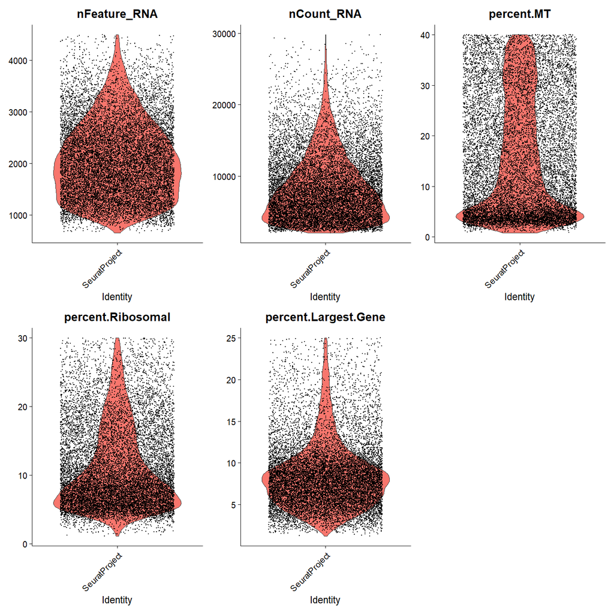

```r
VlnPlot(all.filtered,
        features=c("nFeature_RNA",
                   "nCount_RNA",
                   "percent.MT",
                   "percent.Ribosomal",
                   "percent.Largest.Gene"),
        ncol = 3)
```

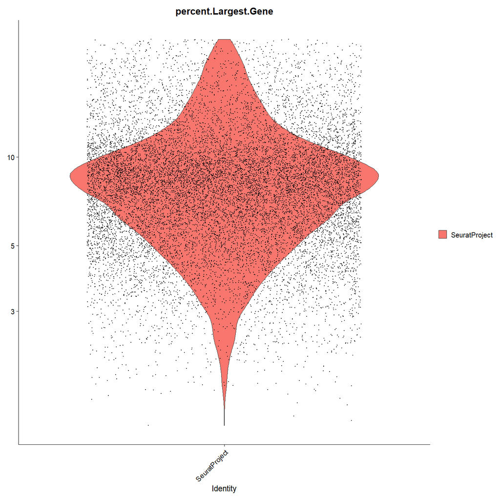

```r
VlnPlot(all.filtered,
        features=c("percent.Largest.Gene"),
        ncol = 1) +
  scale_y_log10()
```

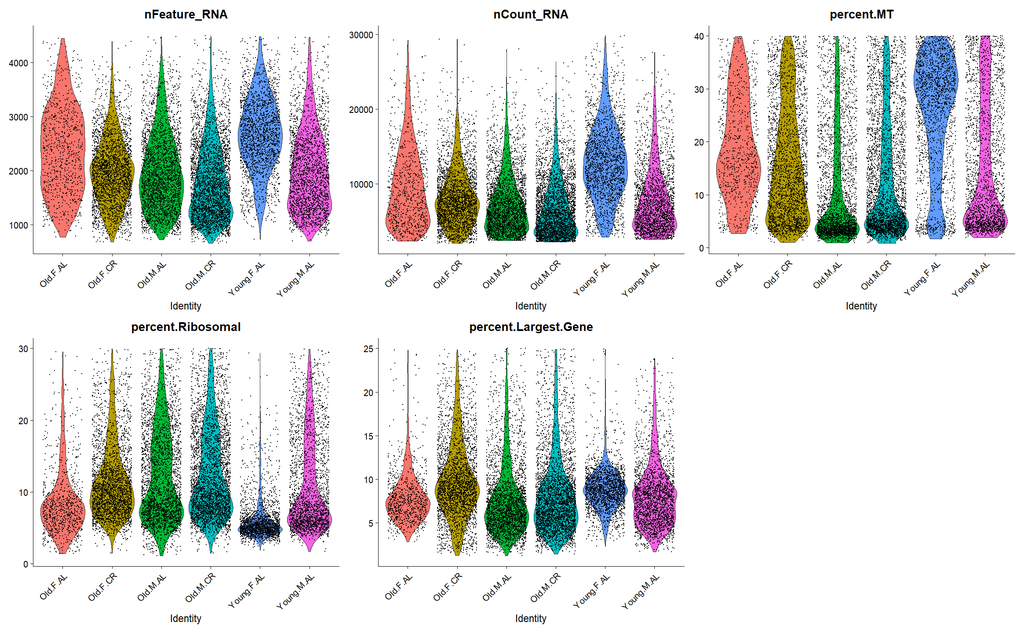

```r
VlnPlot(all.filtered,
        features=c("nFeature_RNA",
                   "nCount_RNA",
                   "percent.MT",
                   "percent.Ribosomal",
                   "percent.Largest.Gene"),
        group.by = "Sample",
        ncol = 3)
```

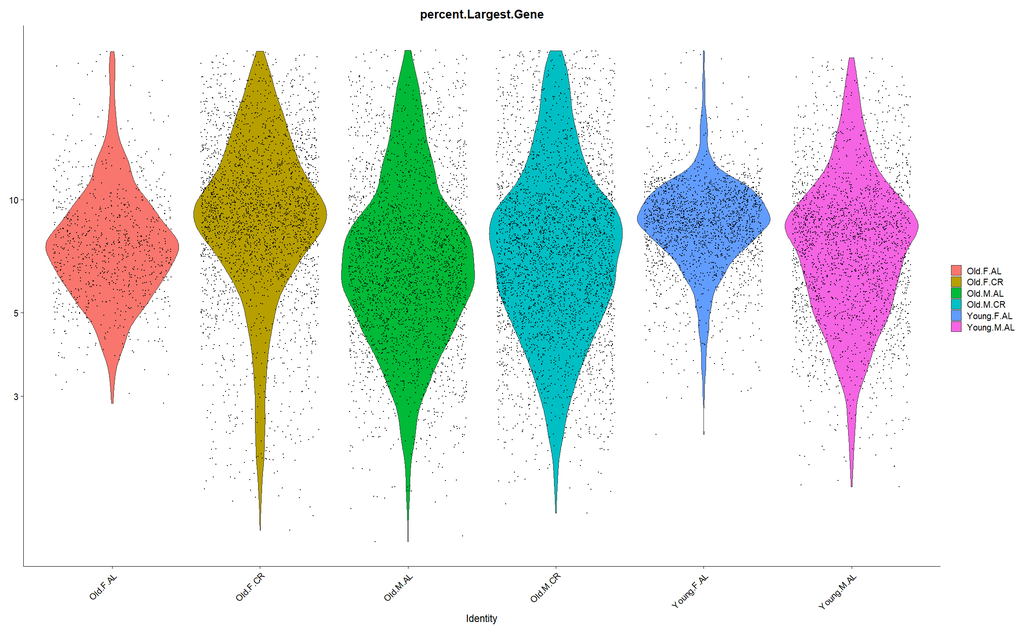

```r
VlnPlot(all.filtered,
        features=c("percent.Largest.Gene"),
        group.by = "Sample",
        ncol = 1) +
  scale_y_log10()
```

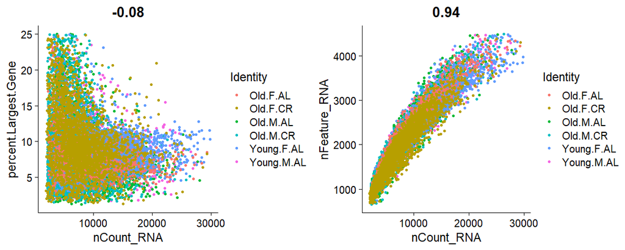

```r
grid.arrange(
FeatureScatter(all.filtered,
               feature1 = "nCount_RNA",
               feature2 = "percent.Largest.Gene",
               group.by = "Sample",
               pt.size = 1),

FeatureScatter(all.filtered,
               "nCount_RNA",
               "nFeature_RNA",
               group.by = "Sample",
               pt.size = 1),

ncol=2)
```

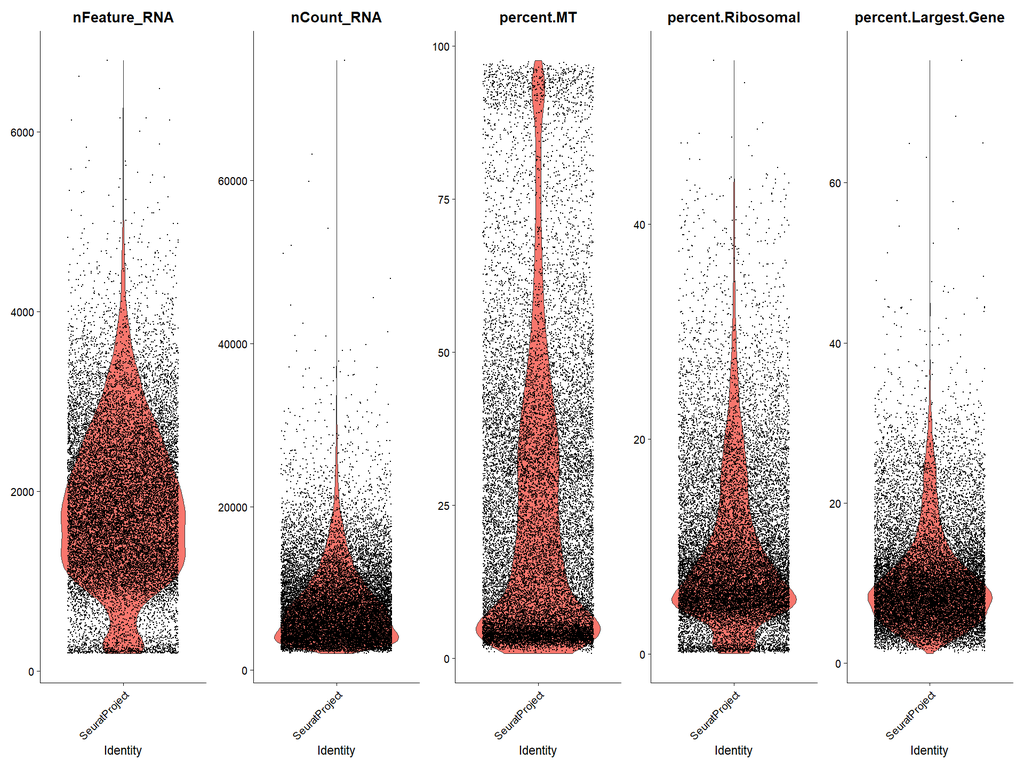

```r
VlnPlot(all.merged,
        features=c("nFeature_RNA",
                   "nCount_RNA",
                   "percent.MT",
                   "percent.Ribosomal",
                   "percent.Largest.Gene"),
        ncol = 5)
```

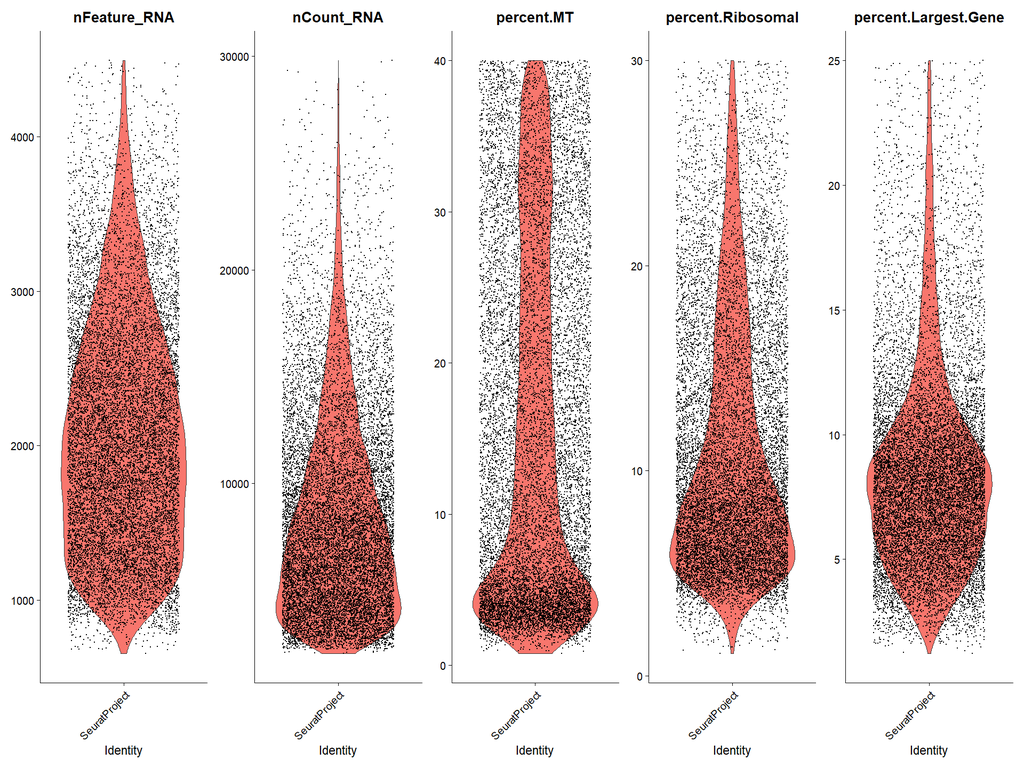

```r
VlnPlot(all.filtered,
        features=c("nFeature_RNA",
                   "nCount_RNA",
                   "percent.MT",
                   "percent.Ribosomal",
                   "percent.Largest.Gene"),
        ncol = 5)
```

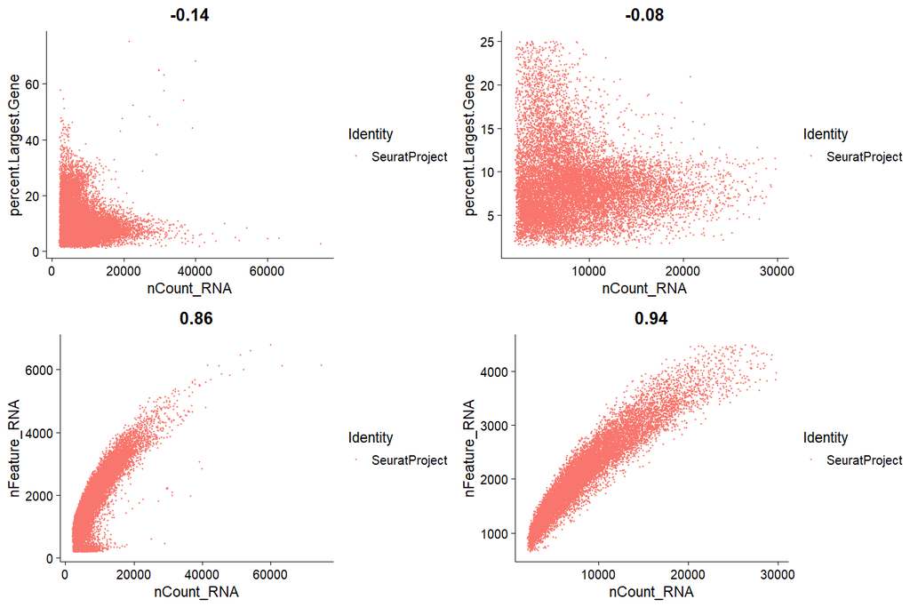

```r
grid.arrange(
FeatureScatter(all.merged,
               feature1 = "nCount_RNA",
               feature2 = "percent.Largest.Gene",
               group.by = "orig.ident",
               pt.size = 0.5),
FeatureScatter(all.filtered,
               feature1 = "nCount_RNA",
               feature2 = "percent.Largest.Gene",
               group.by = "orig.ident",
               pt.size = 0.5),
FeatureScatter(all.merged,
               "nCount_RNA",
               "nFeature_RNA",
               group.by = "orig.ident",
               pt.size = 0.5),
FeatureScatter(all.filtered,
               "nCount_RNA",
               "nFeature_RNA",
               group.by = "orig.ident",
               pt.size = 0.5),
ncol=2)
```

```r
all.filtered <- NormalizeData(all.filtered,
                              normalization.method ="LogNormalize",
                              verbose = T)
```

```r
gene.expression <- apply(all.filtered@assays$RNA@data,
                          1, mean)
gene.expression <- sort(gene.expression,
                        decreasing = T)

head(gene.expression, n=50)
```

```
  AC134224.3      Mt-atp6       Mt-co3       Mt-co1       Mt-co2       Mt-nd1       Mt-cyb       Mt-nd2
    6.096391     5.637419     5.363426     4.998919     4.786065     4.652134     4.539709     4.186416
        Fth1        Rpl41       Mt-nd4 LOC100360087 LOC100360522       Rpl37a          Ubb        Rps18
    4.160500     3.979887     3.635095     3.525939     3.511079     3.462171     3.254486     3.204182
       Rps27        Rpl35         Tpt1          Fau       Tmsb4x        Itm2b  AY172581.24        Rplp0
    3.199239     3.190674     3.189618     3.147846     3.128898     3.124873     3.090670     3.063366
       Cox8a        Uba52 LOC100911847        Rpl19        Rps23       Cox4i1 LOC108352650        Rps16
    3.039380     3.025012     3.005675     2.998415     2.984742     2.981930     2.960290     2.959340
        Rps8         Rps2        Rpl14        Rpl36      Rpl21.3       Rpl27a        Rpl26     Rps27a.1
    2.913048     2.896629     2.893549     2.854848     2.854680     2.839717     2.832928     2.812257
      Rpl23a       Rps15a         Rpl9        Rpl10      Atp5f1b        Rps20 LOC100360781        Rps28
    2.811444     2.810533     2.805709     2.792290     2.788654     2.785729     2.771906     2.764194
     Atp5f1e        Rps17
    2.760385     2.743217
```

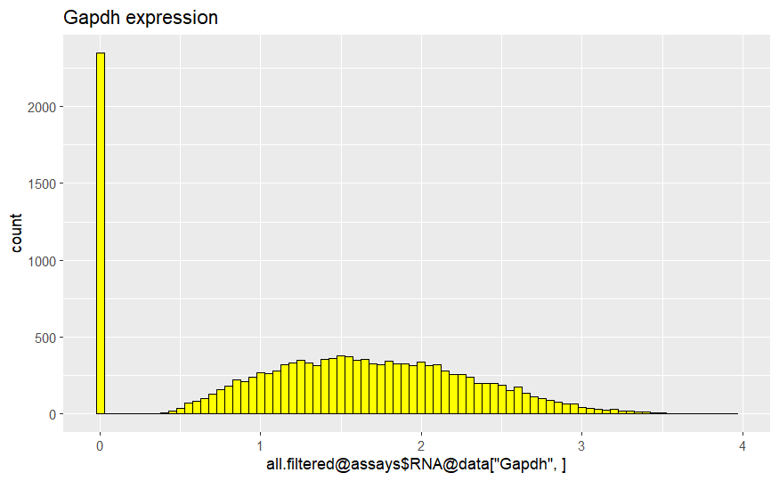

```r
ggplot(mapping = aes(all.filtered@assays$RNA@data["Gapdh",])) +
  geom_histogram(binwidth =0.05, fill="yellow", colour="black") +
  ggtitle("Gapdh expression")
```

# Cell cycle scoring genes

```r
# Seurat cell cycle stage marker genes
cc.genes.updated.2019
```

```
$s.genes
 [1] "MCM5"     "PCNA"     "TYMS"     "FEN1"     "MCM7"     "MCM4"     "RRM1"     "UNG"      "GINS2"    "MCM6"
[11] "CDCA7"    "DTL"      "PRIM1"    "UHRF1"    "CENPU"    "HELLS"    "RFC2"     "POLR1B"   "NASP"     "RAD51AP1"
[21] "GMNN"     "WDR76"    "SLBP"     "CCNE2"    "UBR7"     "POLD3"    "MSH2"     "ATAD2"    "RAD51"    "RRM2"
[31] "CDC45"    "CDC6"     "EXO1"     "TIPIN"    "DSCC1"    "BLM"      "CASP8AP2" "USP1"     "CLSPN"    "POLA1"
[41] "CHAF1B"   "MRPL36"   "E2F8"

$g2m.genes
 [1] "HMGB2"   "CDK1"    "NUSAP1"  "UBE2C"   "BIRC5"   "TPX2"    "TOP2A"   "NDC80"   "CKS2"    "NUF2"    "CKS1B"
[12] "MKI67"   "TMPO"    "CENPF"   "TACC3"   "PIMREG"  "SMC4"    "CCNB2"   "CKAP2L"  "CKAP2"   "AURKB"   "BUB1"
[23] "KIF11"   "ANP32E"  "TUBB4B"  "GTSE1"   "KIF20B"  "HJURP"   "CDCA3"   "JPT1"    "CDC20"   "TTK"     "CDC25C"
[34] "KIF2C"   "RANGAP1" "NCAPD2"  "DLGAP5"  "CDCA2"   "CDCA8"   "ECT2"    "KIF23"   "HMMR"    "AURKA"   "PSRC1"
[45] "ANLN"    "LBR"     "CKAP5"   "CENPE"   "CTCF"    "NEK2"    "G2E3"    "GAS2L3"  "CBX5"    "CENPA"
```

```r
# Non-human format:
str_to_title(cc.genes.updated.2019)
```

```
[1] "C(\"Mcm5\", \"Pcna\", \"Tyms\", \"Fen1\", \"Mcm7\", \"Mcm4\", \"Rrm1\", \"Ung\", \"Gins2\", \"Mcm6\", \"Cdca7\", \"Dtl\", \"Prim1\", \"Uhrf1\", \"Cenpu\", \"Hells\", \"Rfc2\", \"Polr1b\", \"Nasp\", \"Rad51ap1\", \"Gmnn\", \"Wdr76\", \"Slbp\", \"Ccne2\", \"Ubr7\", \"Pold3\", \"Msh2\", \"Atad2\",…
[2] "C(\"Hmgb2\", \"Cdk1\", \"Nusap1\", \"Ube2c\", \"Birc5\", \"Tpx2\", \"Top2a\", \"Ndc80\", \"Cks2\", \"Nuf2\", \"Cks1b\", \"Mki67\", \"Tmpo\", \"Cenpf\", \"Tacc3\", \"Pimreg\", \"Smc4\", \"Ccnb2\", \"Ckap2l\", \"Ckap2\", \"Aurkb\", \"Bub1\", \"Kif11\", \"Anp32e\", \"Tubb4b\", \"Gtse1\", \"Kif20b\…
```

## Predict cell cycle stage

```r
all.filtered <- CellCycleScoring(all.filtered,
                                 s.features = str_to_title(cc.genes.updated.2019$s.genes),
                                 g2m.features = str_to_title(cc.genes.updated.2019$g2m.genes),
                                 set.ident = T)
```

```r
all.filtered[[]]
```

|  | orig.ident | nCount_RNA | nFeature_RNA | Sample | Sex | Age | Diet | percent.MT | percent.Ribosomal | largest_gene | percent.Largest.Gene | S.Score | G2M.Score | Phase | old.ident |
| --- | --- | --- | --- | --- | --- | --- | --- | --- | --- | --- | --- | --- | --- | --- | --- |
| AAACCTGAGCCGTCGT_Kidney_M_Y | SeuratProject | 8868 | 2288 | Young.M.AL | Male | Young | Ad.Libitum | 31.190798 | 4.950383 | Mt-atp6 | 8.085250 | -1.539673e-02 | -8.835070e-03 | G1 | SeuratProject |
| AAACCTGCACTGCCAG_Kidney_M_Y | SeuratProject | 6663 | 2039 | Young.M.AL | Male | Young | Ad.Libitum | 18.490170 | 5.598079 | AC134224.3 | 9.034969 | 7.588261e-03 | -1.237921e-02 | S | SeuratProject |
| AAACCTGCAGACAAAT_Kidney_M_Y | SeuratProject | 9124 | 2198 | Young.M.AL | Male | Young | Ad.Libitum | 4.022359 | 21.777729 | Tmsb4x | 4.088119 | 3.463760e-02 | -1.394029e-02 | S | SeuratProject |
| AAACCTGTCACAGGCC_Kidney_M_Y | SeuratProject | 7407 | 2076 | Young.M.AL | Male | Young | Ad.Libitum | 35.425948 | 3.631700 | Mt-co1 | 8.113946 | -2.586346e-02 | -1.857618e-02 | G1 | SeuratProject |
| AAACCTGTCCCGGATG_Kidney_M_Y | SeuratProject | 10788 | 2356 | Young.M.AL | Male | Young | Ad.Libitum | 36.197627 | 9.519837 | Mt-atp6 | 8.092325 | -4.260038e-02 | 1.844517e-02 | G2M | SeuratProject |
| AAACGGGTCGATAGAA_Kidney_M_Y | SeuratProject | 5440 | 1918 | Young.M.AL | Male | Young | Ad.Libitum | 3.713235 | 15.294118 | AC134224.3 | 7.628676 | -5.020377e-02 | -2.730804e-02 | G1 | SeuratProject |
| AAAGATGCAATGTAAG_Kidney_M_Y | SeuratProject | 4474 | 1000 | Young.M.AL | Male | Young | Ad.Libitum | 5.945463 | 26.665177 | Lyz2 | 5.476084 | -2.850276e-03 | -1.212497e-02 | G1 | SeuratProject |
| AAAGATGGTTGTGGCC_Kidney_M_Y | SeuratProject | 18826 | 4005 | Young.M.AL | Male | Young | Ad.Libitum | 3.707638 | 16.705620 | AC134224.3 | 11.553171 | -6.742618e-02 | -1.621372e-02 | G1 | SeuratProject |
| AAAGCAAAGCGTTGCC_Kidney_M_Y | SeuratProject | 22156 | 4149 | Young.M.AL | Male | Young | Ad.Libitum | 12.669254 | 10.922549 | Mt-atp6 | 3.493410 | 7.707209e-03 | 9.798394e-03 | G2M | SeuratProject |
| AAAGCAACATATGGTC_Kidney_M_Y | SeuratProject | 3952 | 1095 | Young.M.AL | Male | Young | Ad.Libitum | 5.161943 | 22.292510 | AC134224.3 | 5.819838 | -9.945570e-03 | 9.852747e-02 | G2M | SeuratProject |

[output cut: 990 more lines]

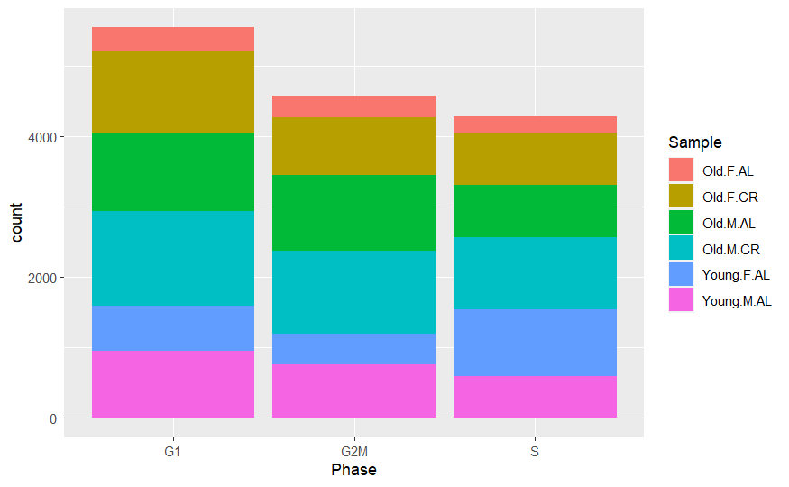

```r
as_tibble(all.filtered[[]]) %>%
  ggplot(aes(Phase,
             fill = Sample)) +
  geom_bar( )
```

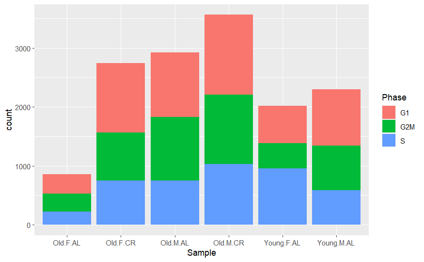

```r
as_tibble(all.filtered[[]]) %>%
  ggplot(aes(Sample,
             fill = Phase)) +
  geom_bar( )
```

## Plot

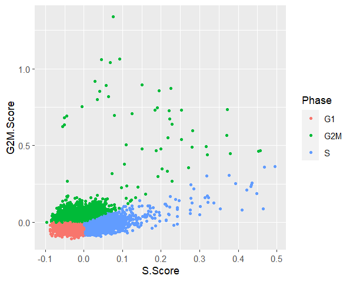

```r
as_tibble(all.filtered[[]]) %>%
  ggplot(aes(x = S.Score,
             y = G2M.Score,
             color=Phase)) +
  geom_point(size = 1)
```

```r
  #coord_cartesian(xlim=c(-0.3,0.3),
   #               ylim=c(-0.3,0.3))
```

## Filter high scoring cells

```r
all.filtered
```

```
An object of class Seurat
16821 features across 14406 samples within 1 assay
Active assay: RNA (16821 features, 0 variable features)
```

```r
all.filtered <- subset(all.filtered,
                       S.Score < 0.2 &
                         G2M.Score < 0.2)
all.filtered
```

```
An object of class Seurat
16821 features across 14312 samples within 1 assay
Active assay: RNA (16821 features, 0 variable features)
```

# Find variable features

```r
all.filtered <- FindVariableFeatures(all.filtered,
                                     selection.method ="vst",
                                     nfeatures = 500)
head(VariableFeatures(all.filtered), 15)
```

```
 [1] "Dcn"     "Ccl5"    "Klk1c9"  "S100a9"  "Slpi"    "S100a8"  "Pi16"    "Acta2"   "Tagln"   "Tff3"    "Slc14a2"
[12] "Mgp"     "Fabp4"   "Calb1"   "Cfd"
```

## Top 15 most highly variable genes

```r
top15 <- head(VariableFeatures(all.filtered), 15)

# plot variable features with and without labels
plot1 <- VariableFeaturePlot(all.filtered)
plot2 <- LabelPoints(plot = plot1,
                     points = top15,
                     repel = T)
```

```
When using repel, set xnudge and ynudge to 0 for optimal results
```

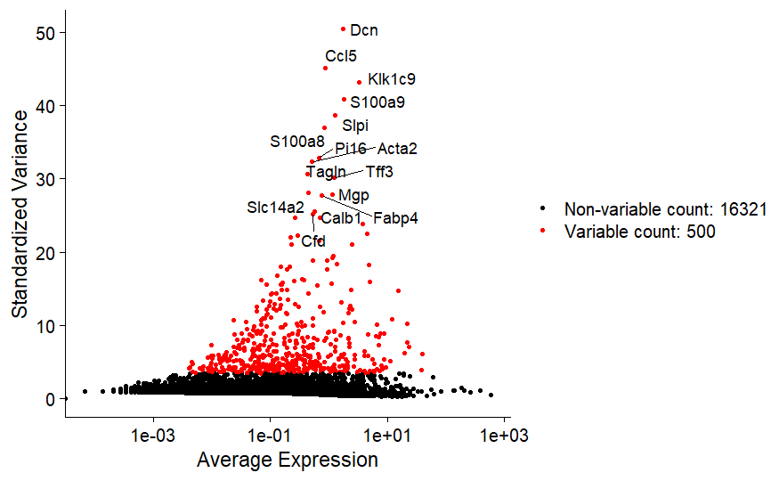

```r
plot2
```

```r
rm(top15,plot1, plot2)
```

```r
variance.data <- as_tibble(HVFInfo(all.filtered),
                           rownames ="Gene")

variance.data <- variance.data %>%
  mutate(hypervariable = Gene %in% VariableFeatures(all.filtered))

head(variance.data, n=10)
```

| Gene | mean | variance | variance.standardized | hypervariable |
| --- | --- | --- | --- | --- |
| LOC102547056 | 0.0056595864 | 0.006326712 | 0.9290004 | FALSE |
| AABR07000159.4 | 0.0006987144 | 0.000698275 | 0.9206362 | FALSE |
| Lrp11 | 0.1285634433 | 0.144465325 | 0.8318162 | FALSE |
| Pcmt1 | 0.1666433762 | 0.204147547 | 0.8764307 | FALSE |
| Nup43 | 0.1067635551 | 0.118710453 | 0.8314970 | FALSE |
| Lats1 | 0.1182224707 | 0.139470867 | 0.8784991 | FALSE |
| Katna1 | 0.0925796534 | 0.098409053 | 0.7933395 | FALSE |
| Ginm1 | 0.0447177194 | 0.047332867 | 0.8004940 | FALSE |
| Ppil4 | 0.1672023477 | 0.190824176 | 0.8160539 | FALSE |
| Zc3h12d | 0.0095723868 | 0.011018698 | 0.9213372 | FALSE |

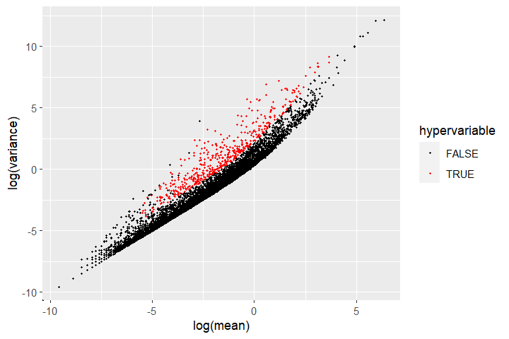

```r
variance.data %>%
  ggplot(aes(log(mean),log(variance),color=hypervariable)) +
  geom_point(size = 0.5) +
  scale_color_manual(values=c("black","red"))
```

# Scaling

Before dimensionality reduction genes will be scaled to have a mean of 0 and a variance of 1. Here is the time to regress unwanted variables e.g. vars.to.regress = c(“S.Score”, “G2M.Score”)

```r
all.filtered <- ScaleData(all.filtered)
                          #vars.to.regress = c("S.Score", "G2M.Score","Age", "Diet", "Sex"))
```